# Behavior Data Analysis

Rayna M Harris

Last updated November 15, 2017

This markdown file is used for behavioral data wrangling, statistical analysis, and data visualization. Figures from this analysis were assembled into this multi-panel plot using Adobe Illustrator. Files used to create the individual figures are saved in the data subdirectory with the prefix 01a.

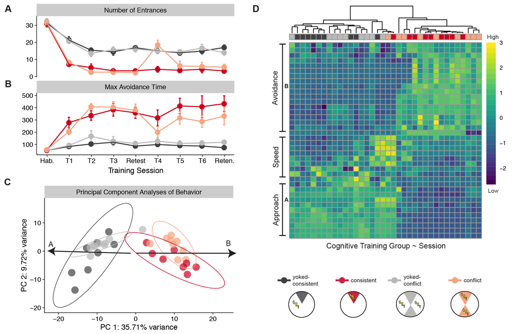

## Setup

```r
## load libraries
library(tidyr) ## for respahing data
library(plyr) ## for renmaing factors
library(dplyr) ## for filtering and selecting rows
library(reshape2) ## for melting dataframe
library(ggplot2) ## for awesome plots!
library(cowplot) ## for some easy to use themes
library(factoextra)  ##pca with vectors
library(car) ## stats
library(superheat) # for kmeans clustered heatmap
library(pheatmap)  # for pretty heatmap
library(viridis) # for awesome color pallette
library(ez)      # for non-parametric ANOVA

## load user-written functions
source("functions_behavior.R")
source("figureoptions.R")

## set output file for figures
knitr::opts_chunk$set(fig.path = '../figures/01_behavior/')
```

## Sample sizes

The ‘APA2’ column describes the four behavioral treatment groups.  
The ‘TrainSessionCombo’ column describes the behvioral training sessions. Here I filter by a single session to calculte the number of mice.

```r
## import output from video tracker program
behavior <- read.csv("../data/01_behaviordata.csv", header = T)

## set level for APA2 then renmae
behavior$APA2 <- factor(behavior$APA2, levels = c("YokedSame", "Same", "YokedConflict","Conflict"))
levels(behavior$APA2) <-  c("yoked-consistent" ,"consistent", "yoked-conflict", "conflict")

# sample sizes
behavior %>%
  filter(TrainSessionCombo == "Retention") %>%
  select(APA2)  %>%  summary()
```

```
##                APA2
##  yoked-consistent:8
##  consistent      :8
##  yoked-conflict  :9
##  conflict        :9
```

## Summary statistics comparing all groups across sessions

```r
# sample sizes
slim1 <- behavior[,c(15,16,14,20:58)] # drop frivolous columns
slim2 <- slim1 # subsequently in this analysis, I use this line to filter rows
slim3 <- slim2[,c(1:3)] # extract experimental design variables
slim4 <- slim2[,c(4:42)]

# Anova
#for(y in names(slim4)){
#  ymod<- summary(aov(slim4[[y]] ~ slim3$APA2 * slim3$TrainSessionCombo ))
#  cat(paste('\nDependent var:', y, '\n'))
#  print(ymod)
#}

# Variables that are significant for training, time, and the interaction
# PolarMaxVal, PolarMinBin, PolarMinVal, PolarSdVal, PolarAvgVal, RayleigLength
# pTimeCW, pTimeOPP, pTimeTarget, TimeTarget, Speed2ndEntr, Path2ndEntr, Time2ndEntr,
# MaxTimeAvoid, NumShock, Dist1stEntr.m, Path1stEntr, Time1stEntr, NumEntrances
```

## Summary statistics comparing Consisten and Conflict behaviors during the T4/C1 training session

1. First, I create some “slim” datasets to look at only the trained animals to look for statistically significant differences between consistent and conflict trained on the T4/C1 training session
2. Then, I used for loops to run statistical tests for all quantitive variables. For space saving, I have quoted out the stats test for space saving and just showed my handwritten notes
3. Then I make a box plot for all variables

```r
names(behavior[c(1:19)]) # various catagorical variables descibing the data
```

```
##  [1] "ID"                   "Year"                 "Genotype"
##  [4] "TrainProtocol"        "TrainSequence"        "TrainGroup"
##  [7] "Day"                  "TrainSession"         "ShockOnOff"
## [10] "PairedPartner"        "Experimenter"         "Housing"
## [13] "TestLocation"         "APA"                  "APA2"
## [16] "TrainSessionCombo"    "pair1"                "pair2"
## [19] "TrainSessionComboNum"
```

```r
names(behavior[c(20:58)]) # All quantitive values collected are
```

```
##  [1] "SdevSpeedArena"     "Linearity.Arena."   "NumEntrances"
##  [4] "Time1stEntr"        "Path1stEntr"        "Speed1stEntr.cm.s."
##  [7] "Dist1stEntr.m."     "NumShock"           "MaxTimeAvoid"
## [10] "Time2ndEntr"        "Path2ndEntr"        "Speed2ndEntr"
## [13] "TimeTarget"         "pTimeTarget"        "pTimeCCW"
## [16] "pTimeOPP"           "pTimeCW"            "RayleigLength"
## [19] "RayleigAngle"       "PolarAvgVal"        "PolarSdVal"
## [22] "PolarMinVal"        "PolarMinBin"        "Min50.RngLoBin"
## [25] "Min50.RngHiBin"     "PolarMaxVal"        "PolarMaxBin"
## [28] "Max50.RngLoBin"     "Max50.RngHiBin"     "AnnularMinVal"
## [31] "AnnularMinBin"      "AnnularMaxVal"      "AnnularMaxBin"
## [34] "AnnularAvg"         "AnnularSd"          "AnnularSkewnes"
## [37] "AnnularKurtosis"    "Speed1"             "Speed2"
```

```r
slim1 <- behavior[,c(15,16,14,20:58)]
slim2 <- slim1 %>% filter(TrainSessionCombo == "T4_C1", APA != "control")
slim3 <- as.data.frame(slim2[,1])
slim4 <- slim2[,c(4:42)]
slim3$APA2 <- factor(slim2$APA2, levels = c("consistent", "conflict"))

# Levene's test for normality
#for(y in names(slim4)){
#  ymod <- leveneTest(slim4[[y]] ~ slim3$APA2)
#  cat(paste('\nDependent var:', y, '\n'))
#  print(ymod)
#}

# Signif. codes:  0 ‘***’ 0.001 ‘**’ 0.01 ‘*’ 0.05 ‘.’ 0.1 ‘ ’ 1
# *** Speed1, Path2ndEntr, Time2ndEntr, Path2ndEntr, Time2ndEntr
# ** Path1stEntr, Time1stEntr
# *  Max50.RngHiBin ,  PolarMaxBin  , PolarMinVal, RayleigAngle, pTimeCW, pTimeOPP,
# .  Speed2, Min50.RngLoBin , TimeTarget, NumShock, NumEntrances
#    AnnularKurtosis, AnnularSkewnes, AnnularSd, AnnularMaxBin, AnnularMaxVal, AnnularMinBin, AnnularMinVal, Max50.RngLoBin, RayleigLength PolarMaxVal, Min50.RngHiBin , PolarMinBin, PolarSdVal, PolarAvgVal, RayleigLength, pTimeTarget, Speed2ndEntr, MaxTimeAvoid, Dist1stEntr.m, Speed1stEntr.cm.s, Linearity.Arena, SdevSpeedArena

for(y in names(slim4)){
  ymod <- wilcox.test(slim4[[y]] ~ slim3$APA2 )
  cat(paste('\nDependent var:', y, '\n'))
  print(ymod)
}
```

```
##
## Dependent var: SdevSpeedArena
##
##  Wilcoxon rank sum test with continuity correction
##
## data:  slim4[[y]] by slim3$APA2
## W = 33, p-value = 0.8098
## alternative hypothesis: true location shift is not equal to 0
```

```
##
## Dependent var: Linearity.Arena.
##
##  Wilcoxon rank sum test with continuity correction
##
## data:  slim4[[y]] by slim3$APA2
## W = 52.5, p-value = 0.1234
## alternative hypothesis: true location shift is not equal to 0
```

```
##
## Dependent var: NumEntrances
##
##  Wilcoxon rank sum test with continuity correction
##
## data:  slim4[[y]] by slim3$APA2
## W = 4.5, p-value = 0.002804
## alternative hypothesis: true location shift is not equal to 0
```

```
##
## Dependent var: Time1stEntr
##
##  Wilcoxon rank sum test with continuity correction
##
## data:  slim4[[y]] by slim3$APA2
## W = 72, p-value = 0.0006258
## alternative hypothesis: true location shift is not equal to 0
```

```
##
## Dependent var: Path1stEntr
##
##  Wilcoxon rank sum test with continuity correction
##
## data:  slim4[[y]] by slim3$APA2
## W = 72, p-value = 0.0005879
## alternative hypothesis: true location shift is not equal to 0
```

```
##
## Dependent var: Speed1stEntr.cm.s.
##
##  Wilcoxon rank sum test with continuity correction
##
## data:  slim4[[y]] by slim3$APA2
## W = 48, p-value = 0.258
## alternative hypothesis: true location shift is not equal to 0
```

```
##
## Dependent var: Dist1stEntr.m.
##
##  Wilcoxon rank sum test with continuity correction
##
## data:  slim4[[y]] by slim3$APA2
## W = 6, p-value = 0.004506
## alternative hypothesis: true location shift is not equal to 0
```

```
##
## Dependent var: NumShock
##
##  Wilcoxon rank sum test with continuity correction
##
## data:  slim4[[y]] by slim3$APA2
## W = 2.5, p-value = 0.001456
## alternative hypothesis: true location shift is not equal to 0
```

```
##
## Dependent var: MaxTimeAvoid
##
##  Wilcoxon rank sum test with continuity correction
##
## data:  slim4[[y]] by slim3$APA2
## W = 49.5, p-value = 0.2104
## alternative hypothesis: true location shift is not equal to 0
```

```
##
## Dependent var: Time2ndEntr
##
##  Wilcoxon rank sum test with continuity correction
##
## data:  slim4[[y]] by slim3$APA2
## W = 72, p-value = 0.0006306
## alternative hypothesis: true location shift is not equal to 0
##
##
## Dependent var: Path2ndEntr
##
##  Wilcoxon rank sum test
##
## data:  slim4[[y]] by slim3$APA2
## W = 72, p-value = 8.227e-05
## alternative hypothesis: true location shift is not equal to 0
```

```
##
## Dependent var: Speed2ndEntr
##
##  Wilcoxon rank sum test with continuity correction
##
## data:  slim4[[y]] by slim3$APA2
## W = 23.5, p-value = 0.2473
## alternative hypothesis: true location shift is not equal to 0
```

```
##
## Dependent var: TimeTarget
##
##  Wilcoxon rank sum test with continuity correction
##
## data:  slim4[[y]] by slim3$APA2
## W = 1, p-value = 0.0008944
## alternative hypothesis: true location shift is not equal to 0
```

```
##
## Dependent var: pTimeTarget
##
##  Wilcoxon rank sum test with continuity correction
##
## data:  slim4[[y]] by slim3$APA2
## W = 3, p-value = 0.001753
## alternative hypothesis: true location shift is not equal to 0
##
##
## Dependent var: pTimeCCW
##
##  Wilcoxon rank sum test
##
## data:  slim4[[y]] by slim3$APA2
## W = 37, p-value = 0.9626
## alternative hypothesis: true location shift is not equal to 0
##
##
## Dependent var: pTimeOPP
##
##  Wilcoxon rank sum test
##
## data:  slim4[[y]] by slim3$APA2
## W = 64, p-value = 0.005512
## alternative hypothesis: true location shift is not equal to 0
##
##
## Dependent var: pTimeCW
##
##  Wilcoxon rank sum test
##
## data:  slim4[[y]] by slim3$APA2
## W = 20, p-value = 0.1388
## alternative hypothesis: true location shift is not equal to 0
```

```
##
## Dependent var: RayleigLength
##
##  Wilcoxon rank sum test with continuity correction
##
## data:  slim4[[y]] by slim3$APA2
## W = 40.5, p-value = 0.6998
## alternative hypothesis: true location shift is not equal to 0
##
##
## Dependent var: RayleigAngle
##
##  Wilcoxon rank sum test
##
## data:  slim4[[y]] by slim3$APA2
## W = 38, p-value = 0.8884
## alternative hypothesis: true location shift is not equal to 0
##
##
## Dependent var: PolarAvgVal
##
##  Wilcoxon rank sum test
##
## data:  slim4[[y]] by slim3$APA2
## W = 57, p-value = 0.0464
## alternative hypothesis: true location shift is not equal to 0
##
##
## Dependent var: PolarSdVal
##
##  Wilcoxon rank sum test
##
## data:  slim4[[y]] by slim3$APA2
## W = 11, p-value = 0.01522
## alternative hypothesis: true location shift is not equal to 0
```

```
##
## Dependent var: PolarMinVal
##
##  Wilcoxon rank sum test with continuity correction
##
## data:  slim4[[y]] by slim3$APA2
## W = 10, p-value = 0.00948
## alternative hypothesis: true location shift is not equal to 0
```

```
##
## Dependent var: PolarMinBin
##
##  Wilcoxon rank sum test with continuity correction
##
## data:  slim4[[y]] by slim3$APA2
## W = 22, p-value = 0.1828
## alternative hypothesis: true location shift is not equal to 0
```

```
##
## Dependent var: Min50.RngLoBin
##
##  Wilcoxon rank sum test with continuity correction
##
## data:  slim4[[y]] by slim3$APA2
## W = 36.5, p-value = 1
## alternative hypothesis: true location shift is not equal to 0
```

```
##
## Dependent var: Min50.RngHiBin
##
##  Wilcoxon rank sum test with continuity correction
##
## data:  slim4[[y]] by slim3$APA2
## W = 44, p-value = 0.4688
## alternative hypothesis: true location shift is not equal to 0
##
##
## Dependent var: PolarMaxVal
##
##  Wilcoxon rank sum test
##
## data:  slim4[[y]] by slim3$APA2
## W = 30, p-value = 0.6058
## alternative hypothesis: true location shift is not equal to 0
```

```
##
## Dependent var: PolarMaxBin
##
##  Wilcoxon rank sum test with continuity correction
##
## data:  slim4[[y]] by slim3$APA2
## W = 34.5, p-value = 0.9231
## alternative hypothesis: true location shift is not equal to 0
```

```
##
## Dependent var: Max50.RngLoBin
##
##  Wilcoxon rank sum test with continuity correction
##
## data:  slim4[[y]] by slim3$APA2
## W = 40.5, p-value = 0.6998
## alternative hypothesis: true location shift is not equal to 0
```

```
##
## Dependent var: Max50.RngHiBin
##
##  Wilcoxon rank sum test with continuity correction
##
## data:  slim4[[y]] by slim3$APA2
## W = 35, p-value = 0.9615
## alternative hypothesis: true location shift is not equal to 0
```

```
##
## Dependent var: AnnularMinVal
##
##  Wilcoxon rank sum test with continuity correction
##
## data:  slim4[[y]] by slim3$APA2
## W = 40, p-value = 0.736
## alternative hypothesis: true location shift is not equal to 0
```

```
##
## Dependent var: AnnularMinBin
##
##  Wilcoxon rank sum test with continuity correction
##
## data:  slim4[[y]] by slim3$APA2
## W = 34, p-value = 0.8797
## alternative hypothesis: true location shift is not equal to 0
##
##
## Dependent var: AnnularMaxVal
##
##  Wilcoxon rank sum test
##
## data:  slim4[[y]] by slim3$APA2
## W = 24, p-value = 0.2766
## alternative hypothesis: true location shift is not equal to 0
```

```
##
## Dependent var: AnnularMaxBin
##
##  Wilcoxon rank sum test with continuity correction
##
## data:  slim4[[y]] by slim3$APA2
## W = 40.5, p-value = 0.6614
## alternative hypothesis: true location shift is not equal to 0
```

```
##
## Dependent var: AnnularAvg
##
##  Wilcoxon rank sum test with continuity correction
##
## data:  slim4[[y]] by slim3$APA2
## W = 41, p-value = 0.6648
## alternative hypothesis: true location shift is not equal to 0
##
##
## Dependent var: AnnularSd
##
##  Wilcoxon rank sum test
##
## data:  slim4[[y]] by slim3$APA2
## W = 34, p-value = 0.8884
## alternative hypothesis: true location shift is not equal to 0
##
##
## Dependent var: AnnularSkewnes
##
##  Wilcoxon rank sum test
##
## data:  slim4[[y]] by slim3$APA2
## W = 34, p-value = 0.8884
## alternative hypothesis: true location shift is not equal to 0
##
##
## Dependent var: AnnularKurtosis
##
##  Wilcoxon rank sum test
##
## data:  slim4[[y]] by slim3$APA2
## W = 33, p-value = 0.8148
## alternative hypothesis: true location shift is not equal to 0
```

```
##
## Dependent var: Speed1
##
##  Wilcoxon rank sum test with continuity correction
##
## data:  slim4[[y]] by slim3$APA2
## W = 48, p-value = 0.2655
## alternative hypothesis: true location shift is not equal to 0
##
##
## Dependent var: Speed2
##
##  Wilcoxon rank sum test
##
## data:  slim4[[y]] by slim3$APA2
## W = 6, p-value = 0.002468
## alternative hypothesis: true location shift is not equal to 0
```

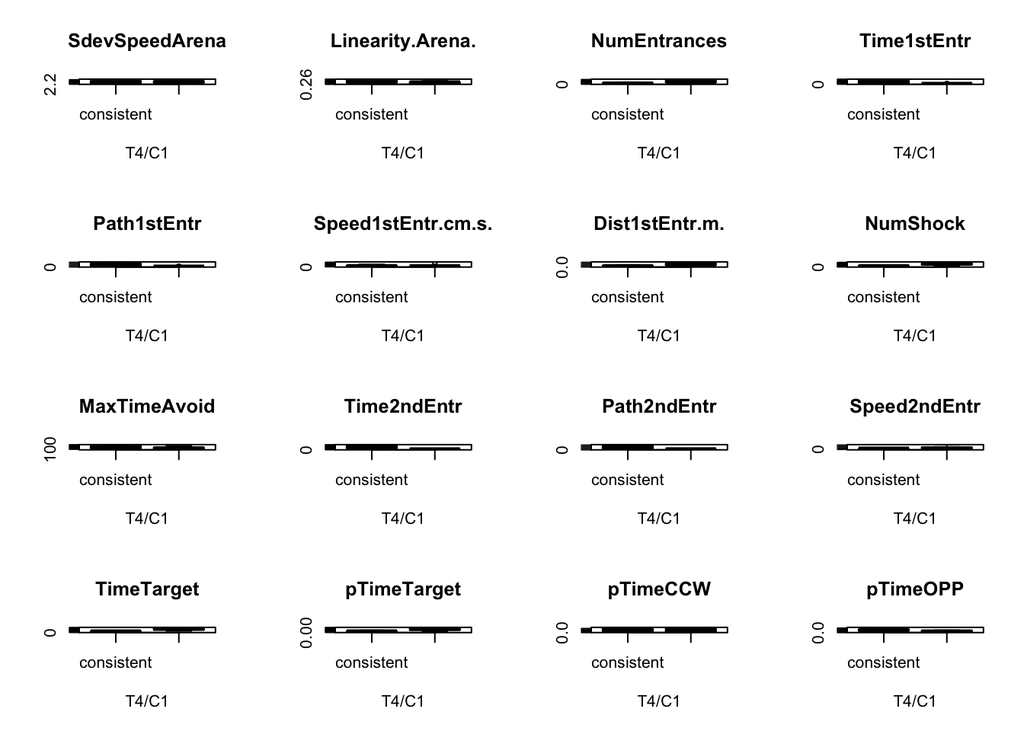

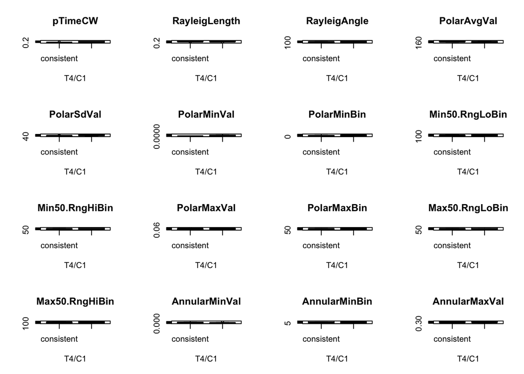

```r
# *** Path2ndEntr
# **  Speed2, PolarMinVal, pTimeOPP, pTimeTarget, TimeTarget, Time2ndEntr, NumShock
# **  Dist1stEntr.m., Path1stEntr , Time1stEntr, NumEntrances
# *   PolarSdVal, PolarAvgVal
# .
#     Speed1, AnnularKurtosis, AnnularSkewnes, AnnularSd, AnnularAvg, AnnularMaxBin,
#     AnnularMaxVal, AnnularMinBin, AnnularMinVal, Max50.RngHiBin , PolarMaxBin,
#     PolarMaxVal, Min50.RngHiBin, Min50.RngLoBin, PolarMinBin, RayleigAngle
#     RayleigLength, pTimeCW, pTimeCCW, Speed2ndEntr, MaxTimeAvoid, Speed1stEntr.cm.s., #     Linearity.Arena., SdevSpeedArena

par(mfrow=c(4,4))
for(y in names(slim4)){
  ymod <- boxplot(slim4[[y]] ~ slim3$APA2,
               main = y,
               xlab = "T4/C1")
}
```

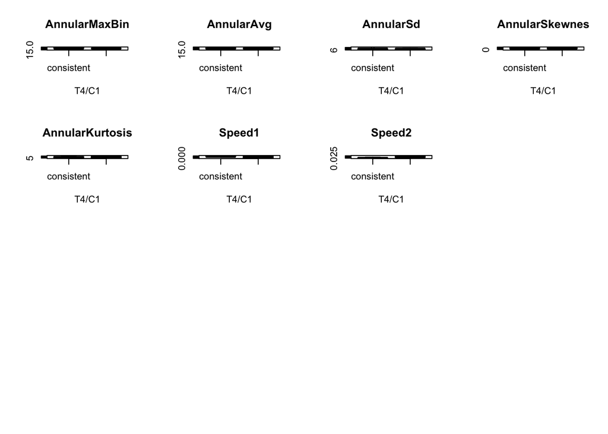

```r
par(mfrow=c(1,1))
```

## Summary statistics comparing Consisten and Conflict behaviors during the T6/C3 training session

```r
slim1 <- behavior[,c(15,16,14,20:58)]
slim2 <- slim1 %>% filter(TrainSessionCombo == "T6_C3", APA != "control")
slim3 <- as.data.frame(slim2[,1])
slim4 <- slim2[,c(4:42)]
slim3$APA2 <- factor(slim2$APA2, levels = c("consistent", "conflict"))

for(y in names(slim4)){
  ymod<- wilcox.test(slim4[[y]] ~ slim3$APA2 )
  cat(paste('\nDependent var:', y, '\n'))
  print(ymod)
}
```

```
##
## Dependent var: SdevSpeedArena
##
##  Wilcoxon rank sum test with continuity correction
##
## data:  slim4[[y]] by slim3$APA2
## W = 21.5, p-value = 0.1774
## alternative hypothesis: true location shift is not equal to 0
##
##
## Dependent var: Linearity.Arena.
##
##  Wilcoxon rank sum test
##
## data:  slim4[[y]] by slim3$APA2
## W = 36, p-value = 1
## alternative hypothesis: true location shift is not equal to 0
```

```
##
## Dependent var: NumEntrances
##
##  Wilcoxon rank sum test with continuity correction
##
## data:  slim4[[y]] by slim3$APA2
## W = 23.5, p-value = 0.2421
## alternative hypothesis: true location shift is not equal to 0
```

```
##
## Dependent var: Time1stEntr
##
##  Wilcoxon rank sum test with continuity correction
##
## data:  slim4[[y]] by slim3$APA2
## W = 42, p-value = 0.5944
## alternative hypothesis: true location shift is not equal to 0
##
##
## Dependent var: Path1stEntr
##
##  Wilcoxon rank sum test
##
## data:  slim4[[y]] by slim3$APA2
## W = 41, p-value = 0.673
## alternative hypothesis: true location shift is not equal to 0
```

```
##
## Dependent var: Speed1stEntr.cm.s.
##
##  Wilcoxon rank sum test with continuity correction
##
## data:  slim4[[y]] by slim3$APA2
## W = 11, p-value = 0.01769
## alternative hypothesis: true location shift is not equal to 0
```

```
##
## Dependent var: Dist1stEntr.m.
##
##  Wilcoxon rank sum test with continuity correction
##
## data:  slim4[[y]] by slim3$APA2
## W = 25, p-value = 0.3081
## alternative hypothesis: true location shift is not equal to 0
```

```
##
## Dependent var: NumShock
##
##  Wilcoxon rank sum test with continuity correction
##
## data:  slim4[[y]] by slim3$APA2
## W = 23.5, p-value = 0.2421
## alternative hypothesis: true location shift is not equal to 0
```

```
##
## Dependent var: MaxTimeAvoid
##
##  Wilcoxon rank sum test with continuity correction
##
## data:  slim4[[y]] by slim3$APA2
## W = 47, p-value = 0.3093
## alternative hypothesis: true location shift is not equal to 0
```

```
##
## Dependent var: Time2ndEntr
##
##  Wilcoxon rank sum test with continuity correction
##
## data:  slim4[[y]] by slim3$APA2
## W = 44.5, p-value = 0.4163
## alternative hypothesis: true location shift is not equal to 0
##
##
## Dependent var: Path2ndEntr
##
##  Wilcoxon rank sum test
##
## data:  slim4[[y]] by slim3$APA2
## W = 31, p-value = 0.673
## alternative hypothesis: true location shift is not equal to 0
```

```
##
## Dependent var: Speed2ndEntr
##
##  Wilcoxon rank sum test with continuity correction
##
## data:  slim4[[y]] by slim3$APA2
## W = 26.5, p-value = 0.3605
## alternative hypothesis: true location shift is not equal to 0
```

```
##
## Dependent var: TimeTarget
##
##  Wilcoxon rank sum test with continuity correction
##
## data:  slim4[[y]] by slim3$APA2
## W = 21.5, p-value = 0.175
## alternative hypothesis: true location shift is not equal to 0
```

```
##
## Dependent var: pTimeTarget
##
##  Wilcoxon rank sum test with continuity correction
##
## data:  slim4[[y]] by slim3$APA2
## W = 27, p-value = 0.4102
## alternative hypothesis: true location shift is not equal to 0
##
##
## Dependent var: pTimeCCW
##
##  Wilcoxon rank sum test
##
## data:  slim4[[y]] by slim3$APA2
## W = 41, p-value = 0.673
## alternative hypothesis: true location shift is not equal to 0
##
##
## Dependent var: pTimeOPP
##
##  Wilcoxon rank sum test
##
## data:  slim4[[y]] by slim3$APA2
## W = 31, p-value = 0.673
## alternative hypothesis: true location shift is not equal to 0
```

```
##
## Dependent var: pTimeCW
##
##  Wilcoxon rank sum test with continuity correction
##
## data:  slim4[[y]] by slim3$APA2
## W = 26, p-value = 0.3603
## alternative hypothesis: true location shift is not equal to 0
```

```
##
## Dependent var: RayleigLength
##
##  Wilcoxon rank sum test with continuity correction
##
## data:  slim4[[y]] by slim3$APA2
## W = 42.5, p-value = 0.5635
## alternative hypothesis: true location shift is not equal to 0
##
##
## Dependent var: RayleigAngle
##
##  Wilcoxon rank sum test
##
## data:  slim4[[y]] by slim3$APA2
## W = 35, p-value = 0.9626
## alternative hypothesis: true location shift is not equal to 0
##
##
## Dependent var: PolarAvgVal
##
##  Wilcoxon rank sum test
##
## data:  slim4[[y]] by slim3$APA2
## W = 68, p-value = 0.0009872
## alternative hypothesis: true location shift is not equal to 0
##
##
## Dependent var: PolarSdVal
##
##  Wilcoxon rank sum test
##
## data:  slim4[[y]] by slim3$APA2
## W = 18, p-value = 0.09272
## alternative hypothesis: true location shift is not equal to 0
```

```
##
## Dependent var: PolarMinVal
##
##  Wilcoxon rank sum test with continuity correction
##
## data:  slim4[[y]] by slim3$APA2
## W = 24, p-value = 0.1657
## alternative hypothesis: true location shift is not equal to 0
```

```
##
## Dependent var: PolarMinBin
##
##  Wilcoxon rank sum test with continuity correction
##
## data:  slim4[[y]] by slim3$APA2
## W = 31, p-value = 0.6121
## alternative hypothesis: true location shift is not equal to 0
```

```
##
## Dependent var: Min50.RngLoBin
##
##  Wilcoxon rank sum test with continuity correction
##
## data:  slim4[[y]] by slim3$APA2
## W = 34.5, p-value = 0.9229
## alternative hypothesis: true location shift is not equal to 0
```

```
##
## Dependent var: Min50.RngHiBin
##
##  Wilcoxon rank sum test with continuity correction
##
## data:  slim4[[y]] by slim3$APA2
## W = 37.5, p-value = 0.9226
## alternative hypothesis: true location shift is not equal to 0
##
##
## Dependent var: PolarMaxVal
##
##  Wilcoxon rank sum test
##
## data:  slim4[[y]] by slim3$APA2
## W = 37, p-value = 0.9626
## alternative hypothesis: true location shift is not equal to 0
```

```
##
## Dependent var: PolarMaxBin
##
##  Wilcoxon rank sum test with continuity correction
##
## data:  slim4[[y]] by slim3$APA2
## W = 35, p-value = 0.9615
## alternative hypothesis: true location shift is not equal to 0
```

```
##
## Dependent var: Max50.RngLoBin
##
##  Wilcoxon rank sum test with continuity correction
##
## data:  slim4[[y]] by slim3$APA2
## W = 37, p-value = 0.9612
## alternative hypothesis: true location shift is not equal to 0
```

```
##
## Dependent var: Max50.RngHiBin
##
##  Wilcoxon rank sum test with continuity correction
##
## data:  slim4[[y]] by slim3$APA2
## W = 35.5, p-value = 1
## alternative hypothesis: true location shift is not equal to 0
```

```
##
## Dependent var: AnnularMinVal
##
##  Wilcoxon rank sum test with continuity correction
##
## data:  slim4[[y]] by slim3$APA2
## W = 50.5, p-value = 0.1777
## alternative hypothesis: true location shift is not equal to 0
```

```
##
## Dependent var: AnnularMinBin
##
##  Wilcoxon rank sum test with continuity correction
##
## data:  slim4[[y]] by slim3$APA2
## W = 23, p-value = 0.185
## alternative hypothesis: true location shift is not equal to 0
##
##
## Dependent var: AnnularMaxVal
##
##  Wilcoxon rank sum test
##
## data:  slim4[[y]] by slim3$APA2
## W = 34, p-value = 0.8884
## alternative hypothesis: true location shift is not equal to 0
```

```
##
## Dependent var: AnnularMaxBin
##
##  Wilcoxon rank sum test with continuity correction
##
## data:  slim4[[y]] by slim3$APA2
## W = 33, p-value = 0.7609
## alternative hypothesis: true location shift is not equal to 0
##
##
## Dependent var: AnnularAvg
##
##  Wilcoxon rank sum test
##
## data:  slim4[[y]] by slim3$APA2
## W = 26, p-value = 0.3704
## alternative hypothesis: true location shift is not equal to 0
##
##
## Dependent var: AnnularSd
##
##  Wilcoxon rank sum test
##
## data:  slim4[[y]] by slim3$APA2
## W = 41, p-value = 0.673
## alternative hypothesis: true location shift is not equal to 0
##
##
## Dependent var: AnnularSkewnes
##
##  Wilcoxon rank sum test
##
## data:  slim4[[y]] by slim3$APA2
## W = 32, p-value = 0.743
## alternative hypothesis: true location shift is not equal to 0
##
##
## Dependent var: AnnularKurtosis
##
##  Wilcoxon rank sum test
##
## data:  slim4[[y]] by slim3$APA2
## W = 31, p-value = 0.673
## alternative hypothesis: true location shift is not equal to 0
##
##
## Dependent var: Speed1
##
##  Wilcoxon rank sum test
##
## data:  slim4[[y]] by slim3$APA2
## W = 20, p-value = 0.1388
## alternative hypothesis: true location shift is not equal to 0
##
##
## Dependent var: Speed2
##
##  Wilcoxon rank sum test
##
## data:  slim4[[y]] by slim3$APA2
## W = 22, p-value = 0.1996
## alternative hypothesis: true location shift is not equal to 0
```

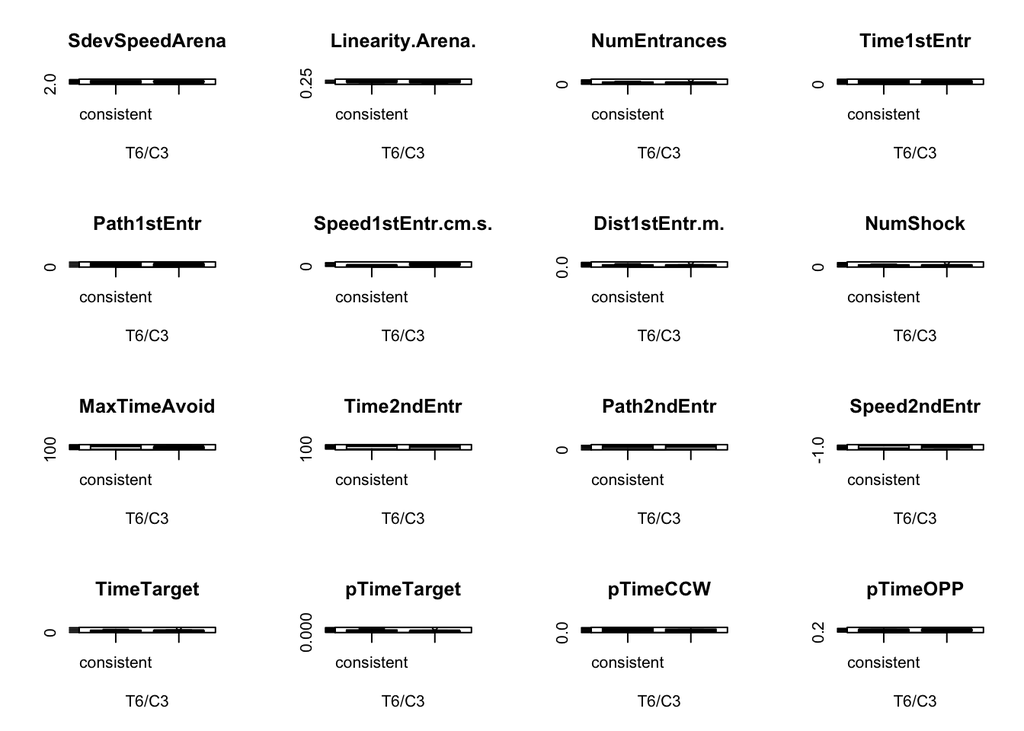

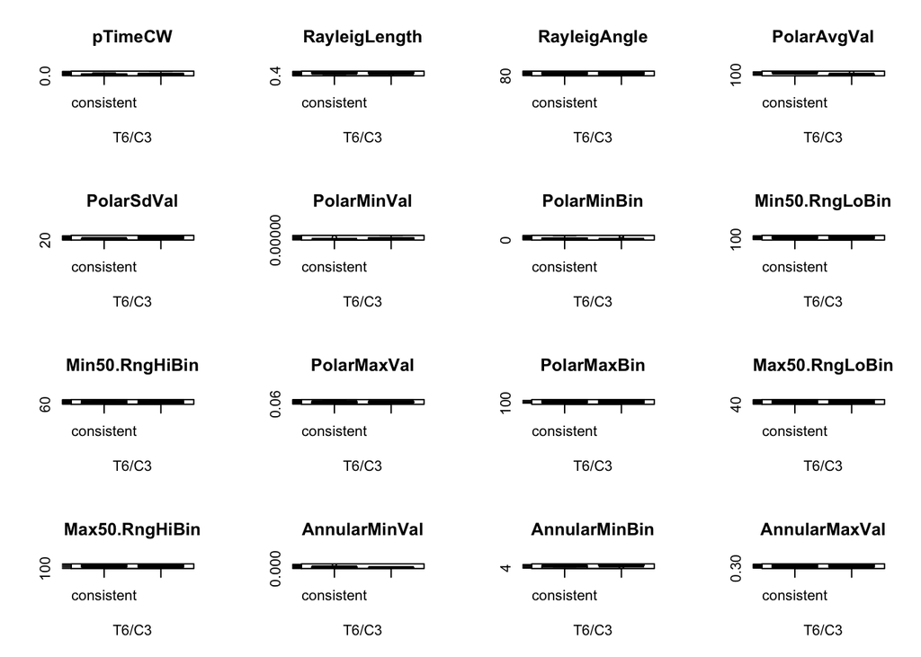

```r
# Signif. codes:  0 ‘***’ 0.001 ‘**’ 0.01 ‘*’ 0.05 ‘.’ 0.1 ‘ ’ 1
# ***
# **  PolarAvgVal,
# *   Speed1stEntr.cm.s.
# .   PolarSdVal,
#     Speed2, Speed1, AnnularKurtosis, AnnularSkewnes, AnnularSd,
#     AnnularAvg, AnnularMaxBin, AnnularMaxVal, AnnularMinBin, AnnularMinVal
#     Max50.RngHiBin, Max50.RngLoBin, PolarMaxBin, PolarMaxVal, Min50.RngHiBin
#     Min50.RngLoBin, PolarMinBin, PolarMinVal, RayleigAngle, RayleigLength,
#     pTimeCW, pTimeOPP, pTimeCCW, pTimeTarget, TimeTarget, Speed2ndEntr,
#     Path2ndEntr, Time2ndEntr, MaxTimeAvoid, NumShock, Dist1stEntr.m.
#     Path1stEntr, Time1stEntr, NumEntrances, Linearity.Arena., SdevSpeedArena

par(mfrow=c(4,4))
for(y in names(slim4)){
  ymod <- boxplot(slim4[[y]] ~ slim3$APA2,
               main = y,
               xlab = "T6/C3")
}
```

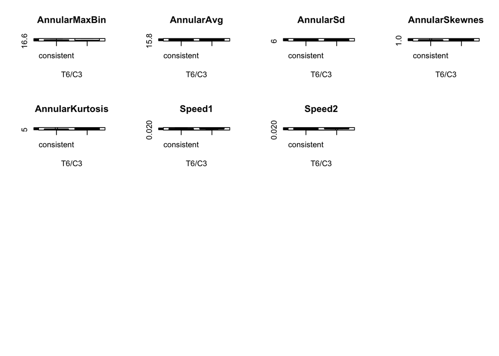

```r
par(mfrow=c(1,1))
```

# Vizualizing Mean and Standard error

To make the point and line graphs, I must create and merge some data frames

```r
## number of entrances
behaviorsummaryNumAPA2 <- dplyr::summarise(group_by(behavior, APA2, TrainSessionComboNum), m = mean(NumEntrances), se = sd(NumEntrances)/sqrt(length(NumEntrances)))

## speed
speedsummary <- dplyr::summarise(group_by(behavior, APA2, TrainSessionComboNum), m = mean(Speed2), se = sd(Speed2)/sqrt(length(Speed2)))

## time second entrance
Time2ndEntr <- dplyr::summarise(group_by(behavior, APA2, TrainSessionComboNum), m = mean(Time2ndEntr), se = sd(Time2ndEntr)/sqrt(length(Time2ndEntr)))

## create the column for faceting
behaviorsummaryNumAPA2$measure <- "Number of Entrances"
speedsummary$measure <- "Speed"
Time2ndEntr$measure <- "Time to 2nd Entrance"

# rbind
threeplots <- rbind(behaviorsummaryNumAPA2,speedsummary, Time2ndEntr)

# set factors
threeplots$APA2 <- factor(threeplots$APA2, levels = c("yoked-consistent" ,"consistent", "yoked-conflict", "conflict"))
threeplots$measure <- factor(threeplots$measure, levels = c("Number of Entrances" ,   "Time to 2nd Entrance", "Speed"))
summary(threeplots)
```

```
##                APA2    TrainSessionComboNum       m
##  yoked-consistent:27   Min.   :1            Min.   :  0.0149
##  consistent      :27   1st Qu.:3            1st Qu.:  0.0351
##  yoked-conflict  :27   Median :5            Median : 14.2222
##  conflict        :27   Mean   :5            Mean   : 59.2463
##                        3rd Qu.:7            3rd Qu.: 48.7872
##                        Max.   :9            Max.   :471.4978
##        se                            measure
##  Min.   :  0.00044   Number of Entrances :36
##  1st Qu.:  0.00392   Time to 2nd Entrance:36
##  Median :  1.51376   Speed               :36
##  Mean   : 13.00903
##  3rd Qu.:  8.37054
##  Max.   :101.93841
```

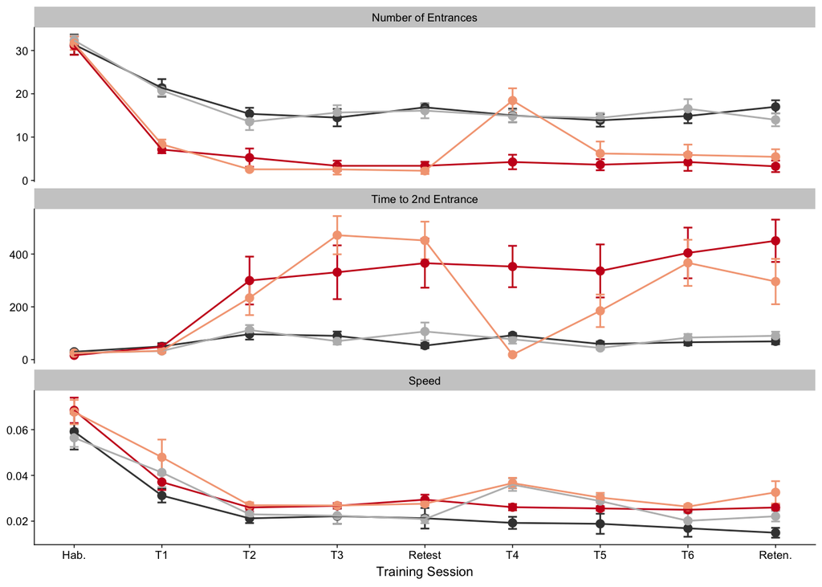

```r
behaviorwrap <- ggplot(threeplots, aes(x=, TrainSessionComboNum, y=m, color=APA2)) +
    geom_errorbar(aes(ymin=m-se, ymax=m+se, color=APA2), width=.1) +
    geom_point(size = 2) +
   geom_line() +
   scale_y_continuous(name= NULL) +
    scale_x_continuous(name="Training Session",
                       breaks = c(1, 2, 3, 4, 5, 6, 7, 8, 9),
                       labels = c( "Hab.", "T1", "T2", "T3",
                                   "Retest", "T4", "T5", "T6", "Reten.")) +
  theme_cowplot(font_size = 8, line_size = 0.25) +
  #background_grid(major = "y", minor = "y") +
  scale_color_manual(values = colorvalAPA00)  +
  theme(legend.position=c(0.7, 0.8))  +
  theme(legend.title=element_blank()) +
  theme(legend.position="none") +
  facet_wrap(~measure, ncol=1, scales = "free_y")
behaviorwrap
```

```r
pdf(file="../figures/01_behavior/threebehaviors.pdf", width=3.25, height=3.75)
plot(behaviorwrap)
dev.off()
```